# Telecom Churn Analysis

# Standard Deviated Group

## Task 1

The dataset we are going to analyze is the “Telecom Churn” dataset, which contains information about US Telecom. For this first task, our objective is to predict customer churn, enabling the company to implement preventative measures to retain clients; as a matter of fact, by identifying customers at high risk of churn, the company can proactively offer targeted promotions to improve retention rates.

### EDA

We start by performing an exploratory data analysis (EDA) to understand the structure of the dataset and the relationships between the variables. Starting with a general overview of the dataset, we can see that it contains 3333 observations and 20 variables. The variables are a mix of numerical and categorical variable; we proceed by factoring the categorical variables in order to better deal with them later.

```
##  [1] "State"                  "Account.length"         "Area.code"
##  [4] "International.plan"     "Voice.mail.plan"        "Number.vmail.messages"
##  [7] "Total.day.minutes"      "Total.day.calls"        "Total.day.charge"
## [10] "Total.eve.minutes"      "Total.eve.calls"        "Total.eve.charge"
## [13] "Total.night.minutes"    "Total.night.calls"      "Total.night.charge"
## [16] "Total.intl.minutes"     "Total.intl.calls"       "Total.intl.charge"
## [19] "Customer.service.calls" "Churn"
```

#### Missing Values and Duplicates

```r
skim(data)
```

Data summary

| Name | data |
| --- | --- |
| Number of rows | 3333 |
| Number of columns | 20 |
| _______________________ |  |
| Column type frequency: |  |
| factor | 4 |
| numeric | 16 |
| ________________________ |  |
| Group variables | None |

**Variable type: factor**

| skim_variable | n_missing | complete_rate | ordered | n_unique | top_counts |
| --- | --- | --- | --- | --- | --- |
| State | 0 | 1 | FALSE | 51 | WV: 106, MN: 84, NY: 83, AL: 80 |
| International.plan | 0 | 1 | FALSE | 2 | No: 3010, Yes: 323 |
| Voice.mail.plan | 0 | 1 | FALSE | 2 | No: 2411, Yes: 922 |
| Churn | 0 | 1 | FALSE | 2 | Fal: 2850, Tru: 483 |

**Variable type: numeric**

| skim_variable | n_missing | complete_rate | mean | sd | p0 | p25 | p50 | p75 | p100 | hist |
| --- | --- | --- | --- | --- | --- | --- | --- | --- | --- | --- |
| Account.length | 0 | 1 | 101.06 | 39.82 | 1.00 | 74.00 | 101.00 | 127.00 | 243.00 | ▂▇▇▂▁ |
| Area.code | 0 | 1 | 437.18 | 42.37 | 408.00 | 408.00 | 415.00 | 510.00 | 510.00 | ▇▁▁▁▃ |
| Number.vmail.messages | 0 | 1 | 8.10 | 13.69 | 0.00 | 0.00 | 0.00 | 20.00 | 51.00 | ▇▁▂▁▁ |
| Total.day.minutes | 0 | 1 | 179.78 | 54.47 | 0.00 | 143.70 | 179.40 | 216.40 | 350.80 | ▁▃▇▅▁ |
| Total.day.calls | 0 | 1 | 100.44 | 20.07 | 0.00 | 87.00 | 101.00 | 114.00 | 165.00 | ▁▁▇▇▁ |
| Total.day.charge | 0 | 1 | 30.56 | 9.26 | 0.00 | 24.43 | 30.50 | 36.79 | 59.64 | ▁▃▇▅▁ |
| Total.eve.minutes | 0 | 1 | 200.98 | 50.71 | 0.00 | 166.60 | 201.40 | 235.30 | 363.70 | ▁▂▇▅▁ |
| Total.eve.calls | 0 | 1 | 100.11 | 19.92 | 0.00 | 87.00 | 100.00 | 114.00 | 170.00 | ▁▁▇▇▁ |
| Total.eve.charge | 0 | 1 | 17.08 | 4.31 | 0.00 | 14.16 | 17.12 | 20.00 | 30.91 | ▁▂▇▅▁ |
| Total.night.minutes | 0 | 1 | 200.87 | 50.57 | 23.20 | 167.00 | 201.20 | 235.30 | 395.00 | ▁▅▇▂▁ |
| Total.night.calls | 0 | 1 | 100.11 | 19.57 | 33.00 | 87.00 | 100.00 | 113.00 | 175.00 | ▁▅▇▂▁ |
| Total.night.charge | 0 | 1 | 9.04 | 2.28 | 1.04 | 7.52 | 9.05 | 10.59 | 17.77 | ▁▅▇▃▁ |
| Total.intl.minutes | 0 | 1 | 10.24 | 2.79 | 0.00 | 8.50 | 10.30 | 12.10 | 20.00 | ▁▃▇▃▁ |
| Total.intl.calls | 0 | 1 | 4.48 | 2.46 | 0.00 | 3.00 | 4.00 | 6.00 | 20.00 | ▇▅▁▁▁ |
| Total.intl.charge | 0 | 1 | 2.76 | 0.75 | 0.00 | 2.30 | 2.78 | 3.27 | 5.40 | ▁▃▇▃▁ |
| Customer.service.calls | 0 | 1 | 1.56 | 1.32 | 0.00 | 1.00 | 1.00 | 2.00 | 9.00 | ▇▅▁▁▁ |

A crucial step in the data analysis process is to check for missing values and duplicates in the dataset to ensure that the data is clean and ready for analysis; in our case we have no missing values and no duplicates. After ensuring dataset integrity, we proceed with the analysis.

#### Univariate and Bivariate Analysis

We proceed by conducting an univariate analysis of the variables in our dataset: our first step is to check the distribution of the target variable ‘Churn’; indeed, we identified the variable ‘Churn’ as the target of our analysis since, as previously stated, the goal of our first task is to build a model to predict customer churn. As shown by the below pie chart,the distribution of the target variable is unbalanced, with 85.5% of the customers not churning and 14.5% churning.

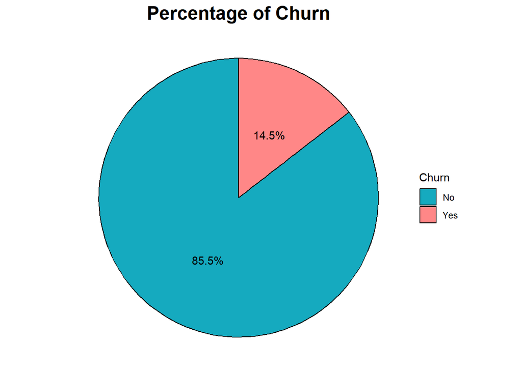

We now proceed with the univariate analysis of the numerical variables in the dataset. We will plot the distribution of the numerical variables by the target variable ‘Churn’ to see if there are any differences in the distribution of the numerical variables between the two levels of the target variable.

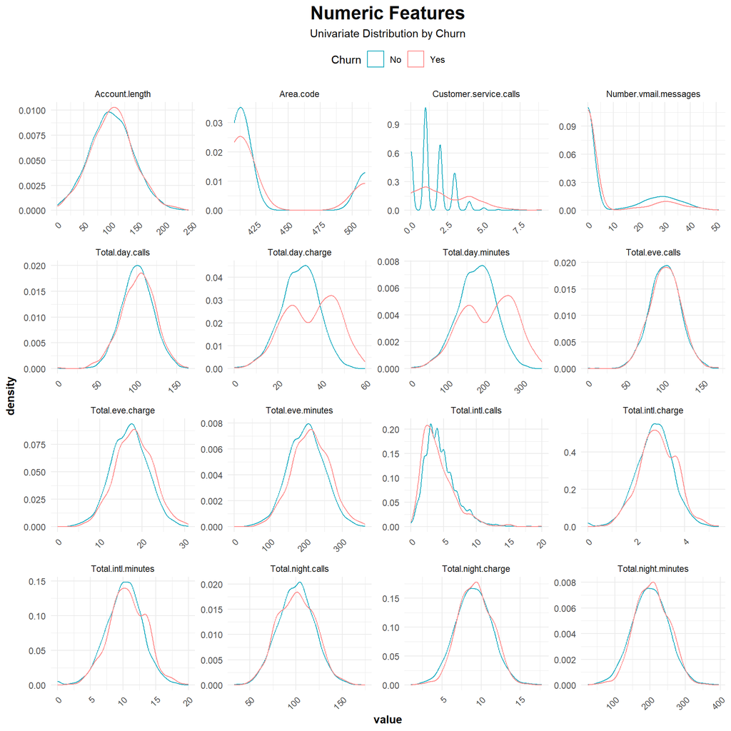

The above univariate analysis of the numerical variables shows that the variables distribution differs remarkably for the two levels of the target variable “Churn” in a couple of cases. Indeed, there’s a noticeable difference in the distribution of **customer service calls**: customers who churned seem to make more customer service calls, which could indicate a relationship between customer satisfaction and churn. It also appears that customers who churned tend to have slightly higher **total day minutes** and **total day charges**; this might suggest that customers with higher usage during the day are more likely to churn. The other variables do not show a significant difference in distribution between the two levels of the target variable.

Another remarkable imbalance can be found in the distribution of both **International.plan** and **Voice.mail.plan**. The majority of customers do not have an international plan nor a voice mail plan; this might suggest that these services are not very popular among customers.

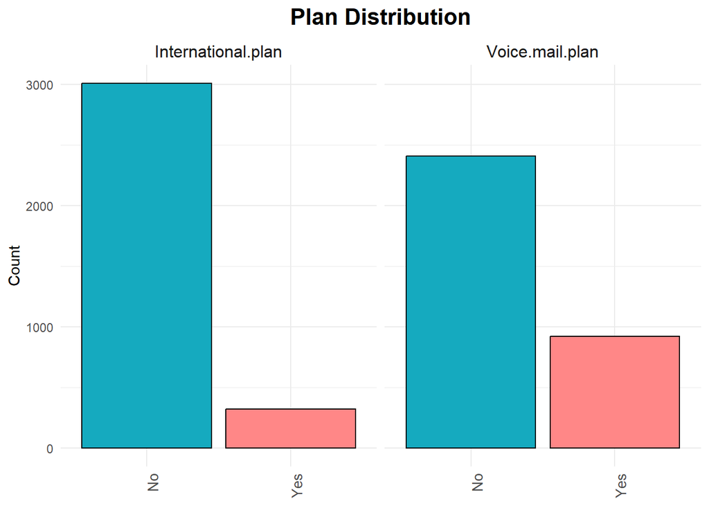

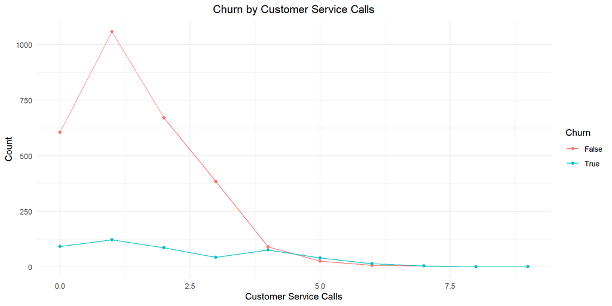

To further prove our hypothesis, we decided to perform the hypothesis testing to determine if the number of customer service calls is associated with the churn rate:

H0: the average number of customer service calls is the same for customers who churned and those who did not

H1: the average number of customer service calls is different for customers who churned and those who did not

```r
chisq.test(data$Customer.service.calls, data$Churn)
```

```
##
##  Pearson's Chi-squared test
##
## data:  data$Customer.service.calls and data$Churn
## X-squared = 342.67, df = 9, p-value < 2.2e-16
```

Since the p-value < 0.05, we reject the null hypothesis; therefore the average number of customer service calls is different for customers who churned and those who did not, which confirms our first assumption.

We now proceed with some more hypothesis testing: we explore the relationship between the **Voice.mail.plan** variable and the target variable **Churn**:

H0: the average churn rate is the same for customers who have a voice mail plan and those who do not

H1: the average churn rate is different for customers who have a voice mail plan and those who do not

```r
chisq.test(data$Voice.mail.plan, data$Churn)
```

```
##
##  Pearson's Chi-squared test with Yates' continuity correction
##
## data:  data$Voice.mail.plan and data$Churn
## X-squared = 34.132, df = 1, p-value = 5.151e-09
```

Since the p-value = 5.151e-09 < 0.05, we reject the null hypothesis; therefore the average churn rate is different for customers who have a voice mail plan and those who do not. Hence we reject the null hypothesis, confirming that the average churn rate is different for customers who have a voice mail plan compared to those who do not.

Lastly, we investigate the relationship between the **International.plan** variable and the target variable **Churn**:

H0: the average churn rate is the same for customers who have an international plan and those who do not

H1: the average churn rate is different for customers who have an international plan and those who do not

```r
chisq.test(data$International.plan, data$Churn)
```

```
##
##  Pearson's Chi-squared test with Yates' continuity correction
##
## data:  data$International.plan and data$Churn
## X-squared = 222.57, df = 1, p-value < 2.2e-16
```

The p-value is less than 2.2e-16, indicating a statistically significant association between having an international plan and customer churn. Therefore, we reject the null hypothesis, confirming that the average churn rate is different for customers who have an international plan compared to those who do not.

To conclude, for the the analysis of categorical variables, we also analysed the distribution of the **State** variable; the below plot shows the distribution of customers across different states in the US.

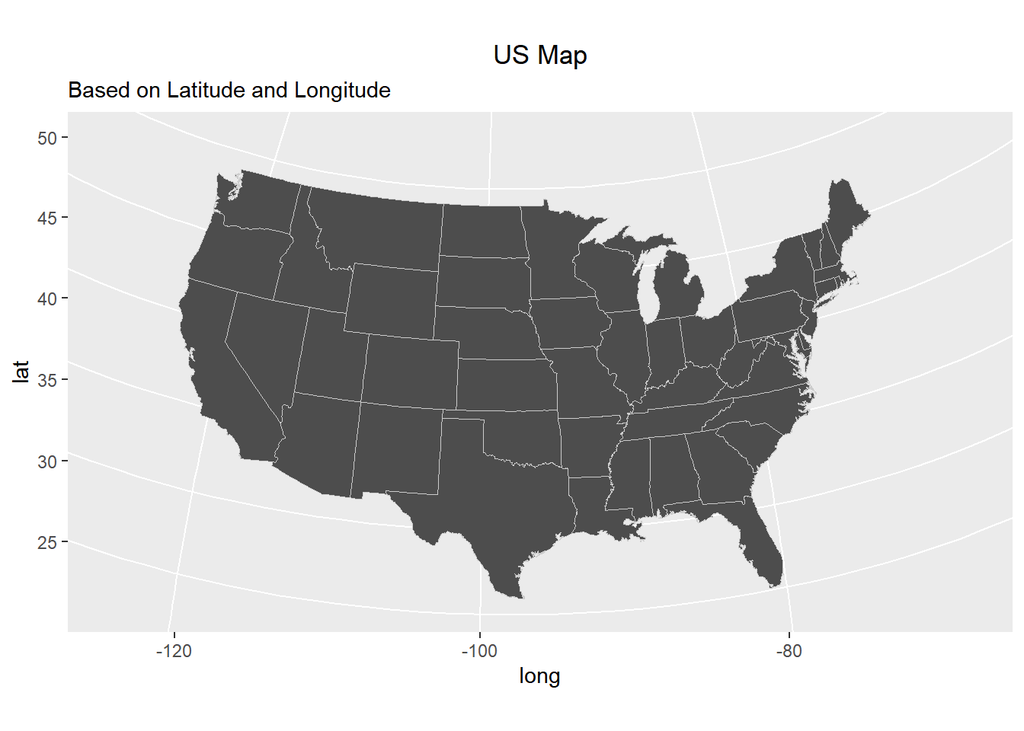

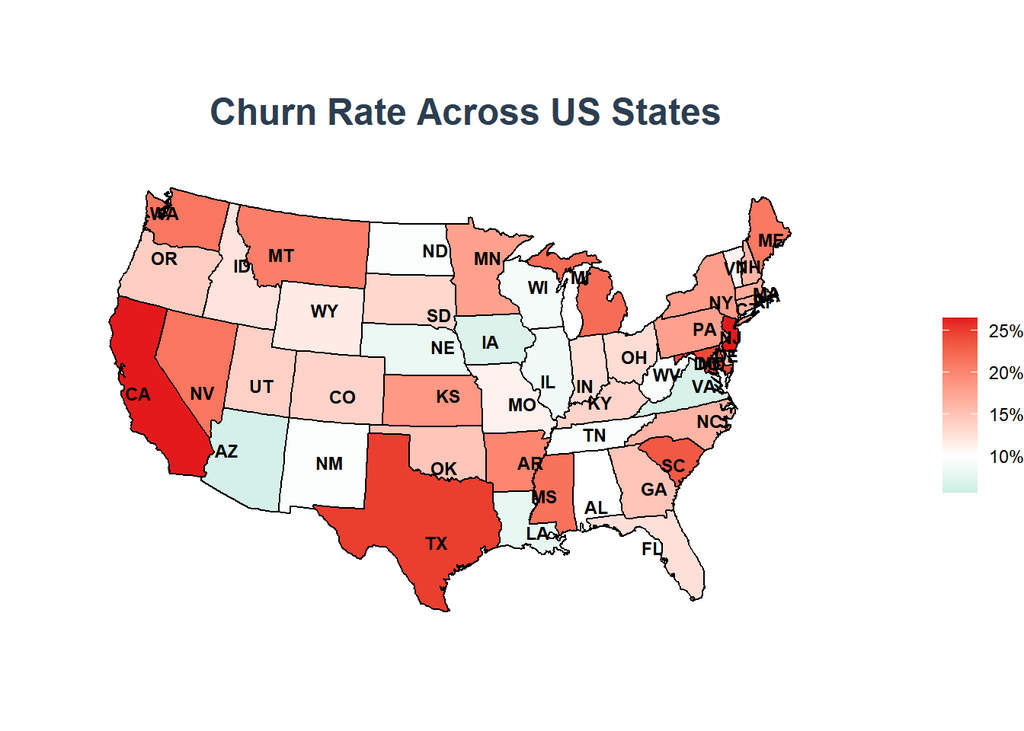

#### Correlation analysis

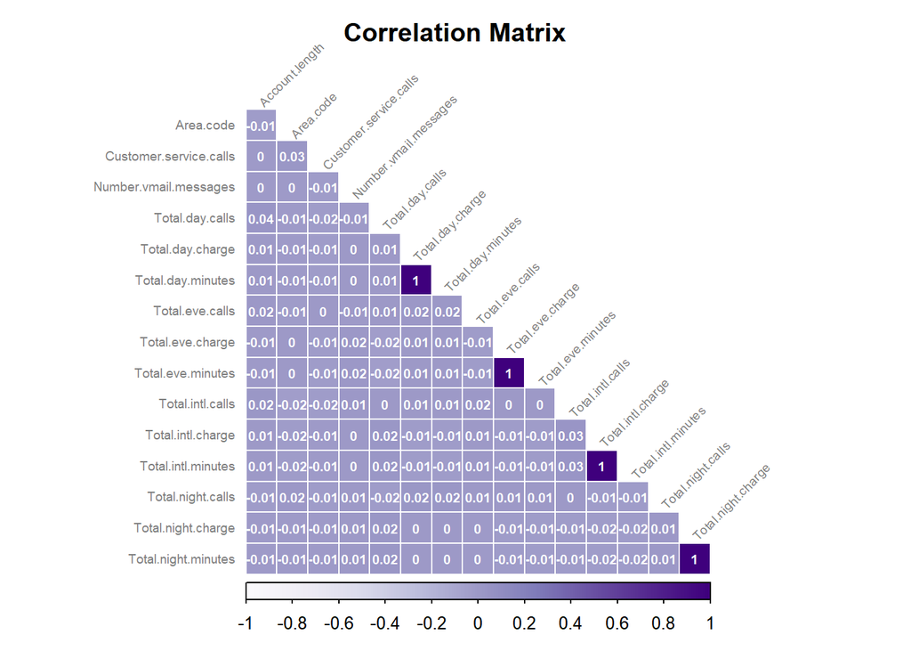

The correlation matrix shows that there is a **perfect correlation between the charge variables and minutes variables** so we can drop all the minutes one: **Total.day.minutes, Total.eve.minutes, Total.night.minutes, Total.intl.minutes**.

### Lower-dimensional models

Before proceeding with the full model we need to focus on some lower dimensional model in order to investigate some interesting relationships between the variables. We decided to proceed by implementing a logistic regression model to understand the relationship between the target variable **“Churn”** and the **Customer Service Calls** variables: indeed, we want to understand if the number of customer service calls influences the churn rate.

```r
service_calls <- data %>%
  filter(Customer.service.calls > 0)
```

We start by visualizing the proportion of churn by the number of customer service calls:

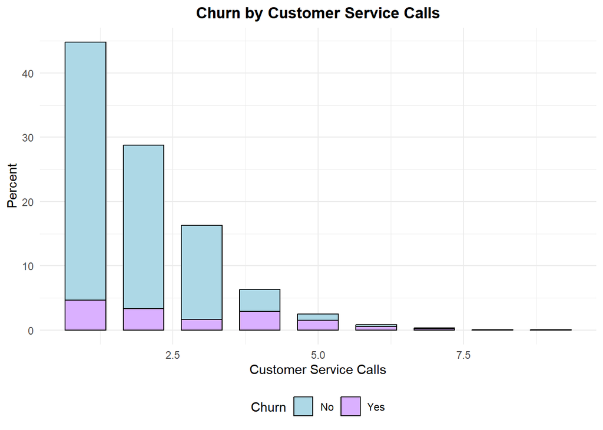

We can see that the churn rate increases as the number of customer service calls increases. Just by looking at the above plot we get the intuition that customers who make more service calls are more likely to churn.

Hence, we proceed by fitting the logistic regression model to understand the relationship between the number of customer service calls and the churn rate:

```r
set.seed(1)
data$Churn <- as.factor(data$Churn)
model <- glm(Churn ~ Customer.service.calls, family = binomial, data = data)
summary(model)
```

```
##
## Call:
## glm(formula = Churn ~ Customer.service.calls, family = binomial,
##     data = data)
##
## Coefficients:
##                        Estimate Std. Error z value Pr(>|z|)
## (Intercept)            -2.49016    0.08631  -28.85   <2e-16 ***
## Customer.service.calls  0.39617    0.03456   11.46   <2e-16 ***
## ---
## Signif. codes:  0 '***' 0.001 '**' 0.01 '*' 0.05 '.' 0.1 ' ' 1
##
## (Dispersion parameter for binomial family taken to be 1)
##
##     Null deviance: 2758.3  on 3332  degrees of freedom
## Residual deviance: 2627.2  on 3331  degrees of freedom
## AIC: 2631.2
##
## Number of Fisher Scoring iterations: 4
```

The output shows a logistic regression analysis where the likelihood of customer churn increases significantly with each additional customer service call, as indicated by the positive coefficient of 0.39617 (p < 2e-16). The model fits the data reasonably with an AIC of 2631.2, suggesting that customer service calls are a relevant predictor of churn. Moreover, the intercept’s p-value (<2e-16) suggests that there is a statistically significant effect of having zero customer service calls on the likelihood of churn and that there is a statistically significant association between the number of customer service calls and an increased likelihood of churn.

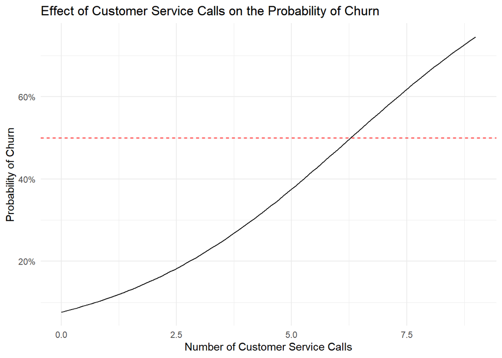

However, we are dealing with a dataset that is highly imbalanced, with 85.5% of the customers not churning and 14.5% churning. This imbalance can lead to biased models that predict the majority class more accurately than the minority class. To address this issue, we will use the undersampling technique to balance the dataset; that is we reduce the number of observations in the majority class (Non-Churn) to match the number of observations in the minority class (Churn).

```r
set.seed(1)
majority_indices <- which(data$Churn == 'False')
minority_count <- sum(data$Churn == 'True')
sampled_indices <- sample(majority_indices, size = minority_count, replace = FALSE)
balanced_data <- data[c(sampled_indices, which(data$Churn == 'True')), ]
balanced_data$Churn <- as.factor(balanced_data$Churn)
balanced_model <- glm(Churn ~ Customer.service.calls, family = binomial, data = balanced_data )
summary(balanced_model)
```

```
##
## Call:
## glm(formula = Churn ~ Customer.service.calls, family = binomial,
##     data = balanced_data)
##
## Coefficients:
##                        Estimate Std. Error z value Pr(>|z|)
## (Intercept)            -0.54195    0.10269  -5.278 1.31e-07 ***
## Customer.service.calls  0.29344    0.04362   6.727 1.73e-11 ***
## ---
## Signif. codes:  0 '***' 0.001 '**' 0.01 '*' 0.05 '.' 0.1 ' ' 1
##
## (Dispersion parameter for binomial family taken to be 1)
##
##     Null deviance: 1339.2  on 965  degrees of freedom
## Residual deviance: 1289.9  on 964  degrees of freedom
## AIC: 1293.9
##
## Number of Fisher Scoring iterations: 4
```

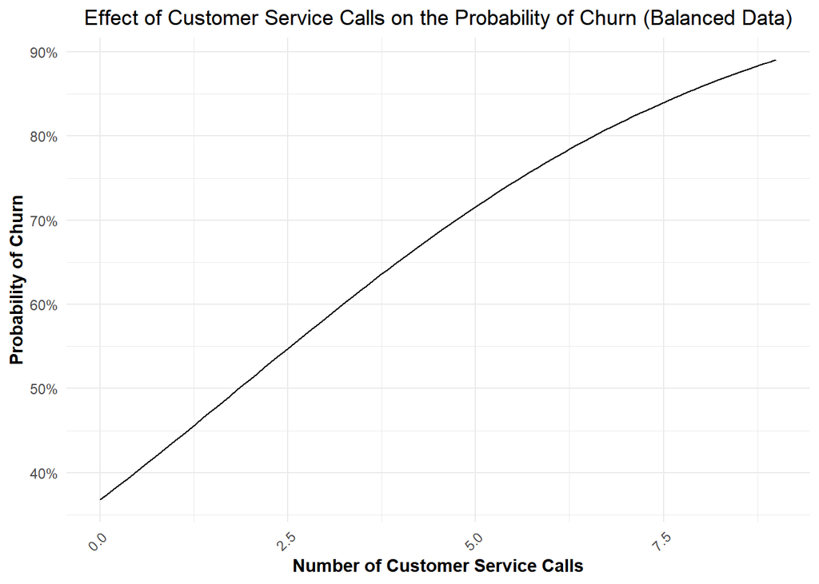

Finally we compare the two confusion matrices of the balanced and unbalanced models:

```
##                 Predicted Positive Predicted Negative
## Actual Positive                  8                475
## Actual Negative                  5               2845
```

```
##                 Predicted Positive Predicted Negative
## Actual Positive                269                214
## Actual Negative                203                280
```

In the unbalanced dataset, the model struggles to correctly identify positive cases, predicting only 8 as positive (true positives) and incorrectly labeling 5 negatives as positive (false positives). In contrast, the balanced model demonstrates better performance in identifying positive cases (269 true positives) but at the cost of more false positives (203). Indeed, this comparison underscores the impact of using balanced data on model performance, particularly in improving the detection of positive cases, which is critical in scenarios like customer churn prediction.

We further proceeded in exploring the interactions between other variables such as the **International.plan** and **Voice.mail.plan** with the target variable **Churn**.

```r
set.seed(1)
data$Churn <- as.factor(data$Churn)
model <- glm(Churn ~ International.plan*Voice.mail.plan, family = binomial, data = data)
summary(model)
```

```
##
## Call:
## glm(formula = Churn ~ International.plan * Voice.mail.plan, family = binomial,
##     data = data)
##
## Coefficients:
##                                          Estimate Std. Error z value Pr(>|z|)
## (Intercept)                               -1.8275     0.0620 -29.477  < 2e-16
## International.planYes                      1.5751     0.1464  10.758  < 2e-16
## Voice.mail.planYes                        -1.0552     0.1669  -6.324 2.55e-10
## International.planYes:Voice.mail.planYes   0.8658     0.3018   2.869  0.00412
##
## (Intercept)                              ***
## International.planYes                    ***
## Voice.mail.planYes                       ***
## International.planYes:Voice.mail.planYes **
## ---
## Signif. codes:  0 '***' 0.001 '**' 0.01 '*' 0.05 '.' 0.1 ' ' 1
##
## (Dispersion parameter for binomial family taken to be 1)
##
##     Null deviance: 2758.3  on 3332  degrees of freedom
## Residual deviance: 2537.8  on 3329  degrees of freedom
## AIC: 2545.8
##
## Number of Fisher Scoring iterations: 5
```

The intercept is very significant with a p-value < 2e-16, indicating a strong effect when both plans are absent. Moreover, both International.planYes and Voice.mail.planYes are highly significant. For the interaction term, while international plans are associated with higher churn, voice mail plans seem to mitigate churn risk. However, customers who have both plans are particularly at risk of churning, possibly due to the higher costs or complexities associated with managing multiple service features.

The last association we investigated was the relationship between the **Customer.service.calls** and **International.plan** variables with the target variable **Churn**.

```r
set.seed(1)
data$Churn <- as.factor(data$Churn)
model <- glm(Churn ~ Customer.service.calls*International.plan, family = binomial, data = data)
summary(model)
```

```
##
## Call:
## glm(formula = Churn ~ Customer.service.calls * International.plan,
##     family = binomial, data = data)
##
## Coefficients:
##                                              Estimate Std. Error z value
## (Intercept)                                  -2.99830    0.10623 -28.225
## Customer.service.calls                        0.50057    0.03971  12.605
## International.planYes                         2.48925    0.20001  12.446
## Customer.service.calls:International.planYes -0.36309    0.09364  -3.878
##                                              Pr(>|z|)
## (Intercept)                                   < 2e-16 ***
## Customer.service.calls                        < 2e-16 ***
## International.planYes                         < 2e-16 ***
## Customer.service.calls:International.planYes 0.000105 ***
## ---
## Signif. codes:  0 '***' 0.001 '**' 0.01 '*' 0.05 '.' 0.1 ' ' 1
##
## (Dispersion parameter for binomial family taken to be 1)
##
##     Null deviance: 2758.3  on 3332  degrees of freedom
## Residual deviance: 2423.8  on 3329  degrees of freedom
## AIC: 2431.8
##
## Number of Fisher Scoring iterations: 5
```

Both International.planYes and Customer.service.calls are highly significant. The interaction term shows that customers with more customer service interactions generally have higher churn rates. However, the negative interaction indicates that the churn-increasing effect of service calls might be mitigated among customers with an international plan, possibly due to different expectations or experiences.

**CONCLUSION UP TO NOW:**

### Preprocessing and feature engineering

In proceeding our analysis we should first deal with the 51 states: we can group them by region; mid west, north east, south east, south west, west.

We’ll use the regions column for the first models to avoid having high-cardinality encoded columns: we store the variable in order to use it later with more robust models (tree-based).

```r
state.column <- data$State
data$State <- NULL
```

Now let’s re-do the chi square:

```r
contingency.table <- table(data$Region, data$Churn)
chisq.test(contingency.table)
```

```
##
##  Pearson's Chi-squared test
##
## data:  contingency.table
## X-squared = 5.9403, df = 4, p-value = 0.2036
```

H0: Region and Churn are independent, H1: Region and Churn are dependent. Since p-value > 0.05, we fail to reject the null hypothesis, therefore the region does not influence the churn rate as the State variable did. Let’s see the distribution of churn by region:

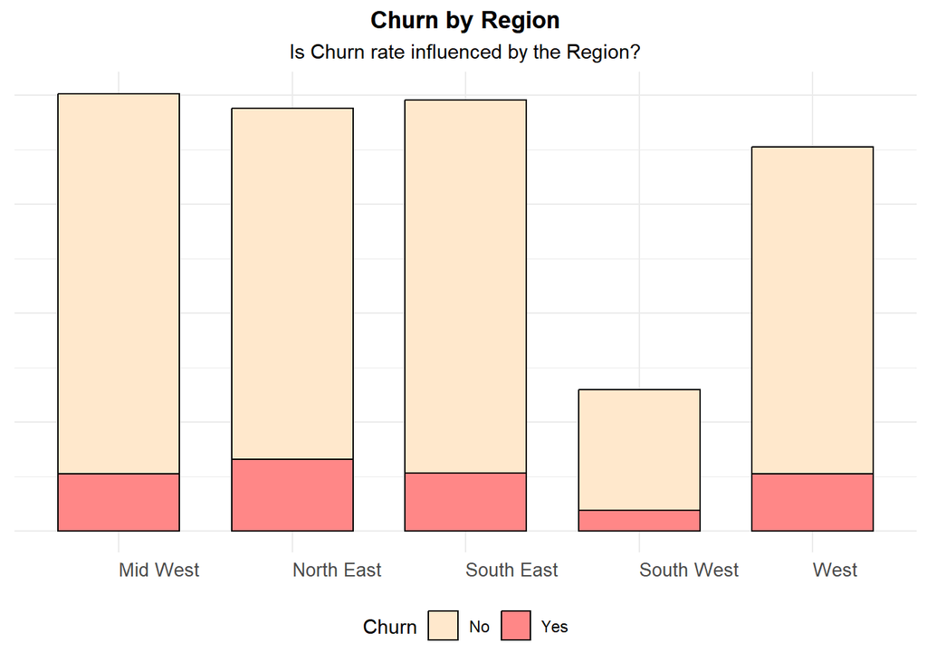

We can see, also from the plot, that the churn rate is not influenced by the region.

#### Splitting the data and scaling

```r
set.seed(1)
ids.train <- sample(1:nrow(data), size = 0.75 * nrow(data), replace = FALSE)
data.train <- data[ids.train,]
data.val <- data[-ids.train,]
```

We oversample the minority class to balance the dataset, and as a result now we have 4260 total observations.

```r
data.train.balanced <- ovun.sample(Churn ~ ., data = data.train, method = "over", N=4260)$data
table(data.train.balanced$Churn)
```

```
##
## False  True
##  2130  2130
```

In order to to prevent certain columns from dominating the model, we scale it using the training data’s mean and standard deviation:

```r
cols_to_scale <- c("Account.length", "Area.code", "Number.vmail.messages", "Total.day.calls", "Total.day.charge", "Total.eve.calls", "Total.eve.charge", "Total.night.calls", "Total.night.charge", "Total.intl.calls", "Total.intl.charge", "Customer.service.calls")

train.mean <- apply(data.train.balanced[, cols_to_scale], MARGIN = 2, FUN = mean)
train.sd <- apply(data.train.balanced[, cols_to_scale], MARGIN = 2, FUN = sd)

data.train.balanced[, cols_to_scale] <- scale(data.train.balanced[, cols_to_scale], center = train.mean, scale = train.sd)
data.val[, cols_to_scale] <- scale(data.val[, cols_to_scale], center = train.mean, scale = train.sd)
```

#### Baseline Logistic Regression Model

It is finally time to start the analysis with the full model. We’ll begin by employing a logistic regression model as our baseline. This approach is straightforward and effective for predicting binary outcomes, which makes it an ideal starting point. By using logistic regression as our benchmark, we can clearly assess the performance improvements offered by more complex models. As we proceed, we’ll compare this baseline model’s accuracy against more sophisticated algorithms to determine whether the increased complexity justifies the potential gains in prediction accuracy. This step-by-step comparison helps us identify which models enhance our analytical capabilities and which may not be worth the additional complexity.

```r
logistic.baseline <- glm(Churn ~ ., data = data.train.balanced, family = "binomial")
```

```
##
## baseline.pred False True
##             0   630   46
##             1    90   68
```

```
##    Accuracy Precision    Recall  F1
## 1 0.8369305 0.5964912 0.4303797 0.5
```

#### AIC and BIC Model Selection

We’ll now proceed with further refining our model by conducting AIC (Akaike Information Criterion) and BIC (Bayesian Information Criterion) analysis.

We performed the **Akaike Information Criterion** (AIC) stepwise selection to identify the most important predictors in the model:

```r
akaike.fw <- step(glm(Churn ~ 1, family = "binomial", data = data.train.balanced), scope = formula(logistic.baseline), direction = "forward")
akaike.back <- step(logistic.baseline, direction = "backward")
akaike.both <- step(logistic.baseline, direction = "both")
```

The AIC analysis results highlight how each variable affects the model’s complexity and fit. For example, variables like `Total.day.charge` and `International.plan` show a substantial increase in the AIC when removed, indicating they are highly significant to the model’s accuracy. Conversely, variables like `Account.length` and `Area.code` have minimal impact on AIC, suggesting they contribute less to model performance.

**Bayesian Information criterion** (BIC) is another criterion to select the best model. We will use the BIC to compare the models selected by the AIC:

```r
bayesian.fw <- step(glm(Churn ~ 1, family = "binomial", data = data.train.balanced), scope = formula(logistic.baseline), direction = "forward", k = log(nrow(data.train.balanced)))
bayesian.back <- step(logistic.baseline, direction = "backward", k = log(nrow(data.train.balanced)))
bayesian.both <- step(logistic.baseline, direction = "both", k = log(nrow(data.train.balanced)))
```

Considering bidirectional elimination of both methods, BIC is more stringent than AIC: it removes all region-related variables, favoring a simpler model. This stricter approach by BIC contrasts with AIC’s tendency to keep more variables for a better fit.

After that we compare the validation set results:

The results show that the model selected by the AIC method performs slightly better than the one selected by the BIC method. The AIC model has a higher accuracy, precision, recall, and F1 score: maybe dropping all the region features as BIC does is too big of a loss of informations.

**AIC**:

```
##
## akaike.preds False True
##            0   629   46
##            1    91   68
```

```
##    Accuracy Precision   Recall        F1
## 1 0.8357314 0.5964912 0.427673 0.4981685
```

**BIC**:

```
##
## bayesian.preds False True
##              0   627   48
##              1    93   66
```

```
##    Accuracy Precision    Recall        F1
## 1 0.8309353 0.5789474 0.4150943 0.4835165
```

#### ROC Curves

The AUC-ROC curve is a graphical representation of the model’s ability to discriminate between positive and negative classes. We plot the ROC curves for the full model, the AIC model, and the BIC model to compare their performance:

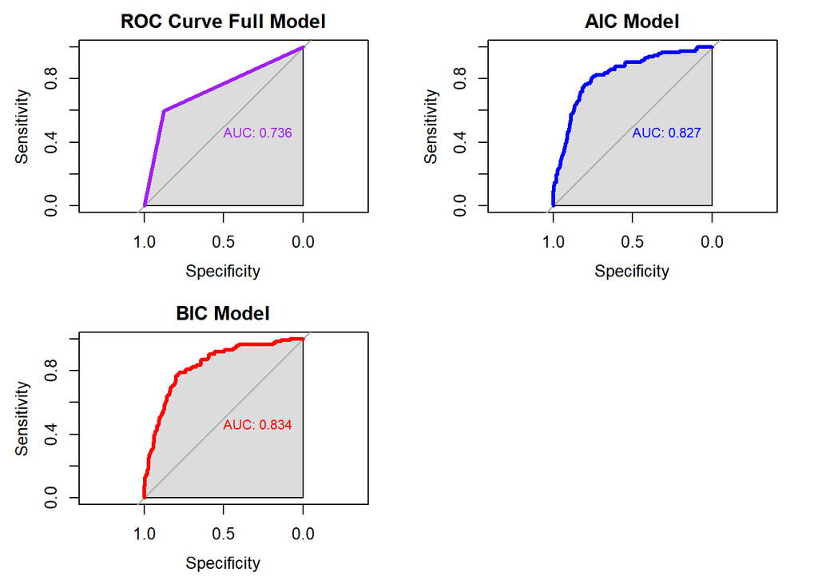

#### LASSO and RIDGE REGULARIZATION

We are now exploring Lasso and Ridge regression techniques. Lasso (Least Absolute Shrinkage and Selection Operator) helps in enhancing model accuracy and interpretability by reducing less important features to zero. Ridge regression, on the other hand, minimizes the influence of less important features through shrinkage but keeps all variables in the model.

We decided to leverage both LASSO and Ridge regularization methods to fine-tune our logistic regression model, aiming to enhance its predictive capabilities while addressing potential multicollinearity and feature redundancy.

**LASSO**:

```r
set.seed(1)
ctrl <- trainControl(method = "cv", number = 10)
lasso <- train(Churn ~ ., data = data.train.balanced, method = "glmnet", metric = "Accuracy", trControl = ctrl, tuneGrid = expand.grid(alpha = 1, lambda = seq(0, 0.15, length = 30)))
max(lasso$results$Accuracy)
```

```
## [1] 0.7741784
```

```r
lasso$bestTune
```

```
##   alpha lambda
## 1     1      0
```

```r
lasso.predict <- predict(lasso, data.val)
lasso.cm <- table(lasso.predict, data.val$Churn)
lasso.metrics <- get.metrics(lasso.cm)
```

After tuning over a grid of parameters, the highest achieved accuracy is 77.42%. The optimal regularization parameters selected are alpha = 1 and lambda = 0, indicating LASSO regularization without penalty.

**RIDGE**:

```r
set.seed(1)
ridge <- train(Churn ~ ., data = data.train.balanced, method = "glmnet", metric = "Accuracy", trControl = ctrl, tuneGrid = expand.grid(alpha = 0, lambda = seq(0, 0.15, length = 30)))
max(ridge$results$Accuracy)
```

```
## [1] 0.771831
```

```r
ridge$bestTune
```

```
##   alpha     lambda
## 3     0 0.01034483
```

```r
ridge.predict <- predict(ridge, data.val)
ridge.cm <- table(ridge.predict, data.val$Churn)
ridge.metrics <- get.metrics(ridge.cm)
```

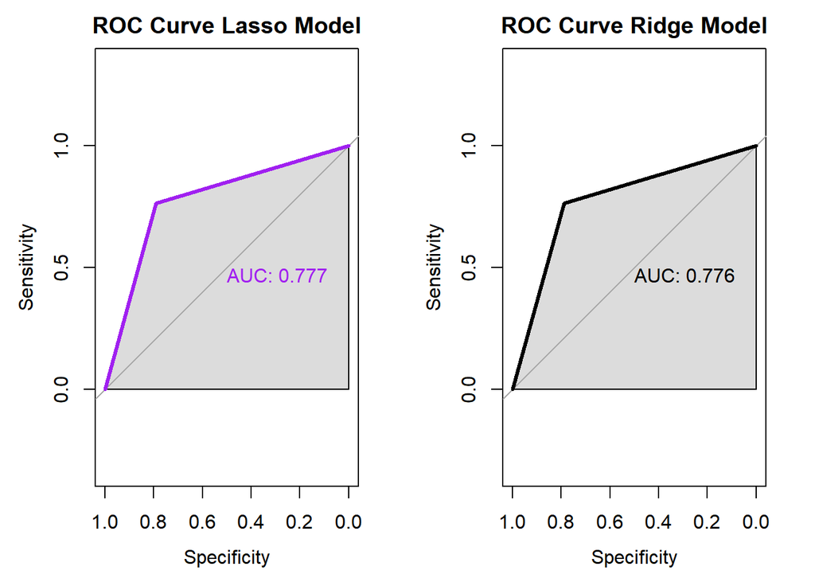

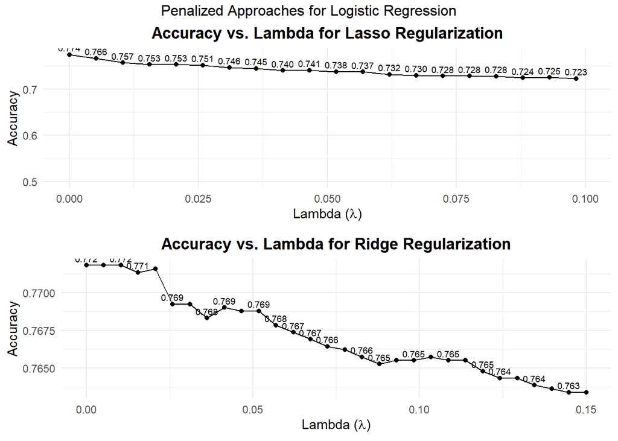

Now let’s compare the metrics obtained with the different models:

```
##            Model  Accuracy Precision    Recall  F1_Score       AUC
## 1         Akaike 0.8357314 0.5964912 0.4276730 0.4981685 0.8272539
## 2       Bayesian 0.8309353 0.5789474 0.4150943 0.4835165 0.8343689
## 3  Full Logistic 0.8369305 0.5964912 0.4303797 0.5000000 0.7357456
## 4 Logistic Ridge 0.7853717 0.7631579 0.3640167 0.4929178 0.7760234
## 5 Logistic Lasso 0.7877698 0.7631579 0.3670886 0.4957265 0.7774123
```

#### TREES

From now on we are studying other models and comparing the metrics with the logistic regression we chose as baseline model:

- **Decision trees**
- **Random Forest**
- **XGBOOST**